# Lexical Decision Data Processing

## Overview

This document presents the analysis code for the lexical decision task reported in *Relating Scalar Inference and Alternative Activation: A View from the Rise-Fall-Rise Tune in American English* (Sostarics, Ronai, and Cole 2024). We only include the code related to the specific analyses and figures presented in the paper.

### Important notes

In this document, HIGHER refers to the participant HEARS the HIGHER alternative and SEES the LOWER alternative. LOWER refers to the participant HEARS the LOWER alternative and SEES the HIGHER alternative. This is the OPPOSITE of how it’s discussed in the paper. In plots the results are re-labeled to match what’s in the paper. So, when you see differences of `lower-higher` here, this means a difference of `(RT when higher alternative is shown) - (RT when lower alternative is shown)`

`contrastable` and `sosdiss2` are available on my github at `github.com/tsostarics`. The former is useful for anyone, the latter provides reusable functions for my dissertation.

## Setup

```r
library(tidyverse)    # Data wrangling
library(contrastable) # Contrast coding
library(sosdiss2)     # Helpers used across other projects
library(brms)         # Bayesian modeling
library(cmdstanr)     # Stan backend
library(rstan)        # stan backend, loo_compare uses it
library(bayestestR)   # Bayesian helpers
library(tidybayes)    #
library(ggdist)       #
library(ggnewscale)   # Plot scale helpers
library(here)         # Directory management
library(broom.mixed)
options(keep.source = TRUE, width = 180)

# pulled out of {sosdiss2}
plot_posterior_rt_draws <- function(condition_difference_draws,
                                    scale = 1.2,
                                    slab_scale = 1,
                                    facet_labels = c('lower'  = "Hear tough, see impossible",
                                                     'higher' = 'Hear impossible, see tough'),
                                    debug_red = FALSE,
                                    ...) {
  percent_change_df <- compute_percent_change(condition_difference_draws)

  plot_df <-
    condition_difference_draws |>
    dplyr::left_join(dplyr::select(percent_change_df, condition, tune, past_95))

  condition_difference_draws |>
    ggplot(aes(x = tune, y = difference)) +
    ggplot2::geom_hline(yintercept = 0,
                        linetype = 'dashed',
                        color = 'gray10')+
    ggdist::stat_histinterval(data = dplyr::filter(plot_df, !past_95 | debug_red),
                              aes(fill = factor(after_stat(.width))),
                              point_interval = 'mean_qi',
                              .width = c(.5, .89, .95),
                              slab_linewidth = .1,
                              height = 1,
                              scale = .95,
                              trim = FALSE,
                              outline_bars = TRUE) +
    ggplot2::scale_fill_brewer(palette = "Greys", direction = -1) +
    ggnewscale::new_scale_fill() +
    ggdist::stat_histinterval(data = dplyr::filter(plot_df, past_95),

                              aes(fill = factor(after_stat(.width))),
                              point_interval = 'mean_qi',
                              .width = c(.5, .89, .95),
                              slab_linewidth = .5,
                              height = 1,
                              alpha = ifelse(debug_red, .5, 1),
                              scale = slab_scale * .95, # Needed to match the scaling of the gray ones
                              color = "#380202",
                              point_fill = "#fee0d2",
                              fatten_point = 2.25,
                              shape = 23,
                              trim = FALSE,
                              outline_bars = TRUE) +
    scale_thickness_shared()+
    ggplot2::scale_fill_brewer(palette = "Reds", direction = -1) +

    ggplot2::geom_text(data = percent_change_df,
                       aes(x = tune,
                           y = difference,
                           label = pct_label),
                       position = position_nudge(x=.09,y=.002),
                       angle = -15,
                       hjust = 0,
                       fontface = "bold",
                       size = 4,
                       color = 'white') +
    ggplot2::facet_grid(~condition,
                        labeller = labeller(.cols = facet_labels)) +
    ggplot2::theme_bw(base_size = 16*scale) +
    ggplot2::coord_cartesian(xlim = c(.5,7.1),
                             # ylim = c(-.05, .05),
                             clip = TRUE,
                             expand = FALSE)+
    scale_y_continuous(labels = scales::label_percent()) +
    ggplot2::theme(panel.grid = element_line(linewidth = .3),
                   panel.grid.minor.x = element_blank(),
                   legend.position = 'none') +
    ggplot2::xlab("Tune") +
    ggplot2::ylab("% Difference\nfrom Condition Mean")
}
```

## Data wrangling

Load the raw experimental data and lexical measures, processes the data to the final dataset fed to the model.

```r
exp_data <- readRDS("Data/exp_data.rds")

# Load the lexical measures
metrics <-
  readr::read_csv(here::here("Data/elexicon_metrics.csv")) |>
  dplyr::mutate(Word = toupper(Word),
                center_log_freq = Log_Freq_HAL - mean(Log_Freq_HAL),
                center_length = Length - mean(Length),
                center_nsyl =  NSyll - median(NSyll))

flag_trial_outliers <- function(data,
                                by = 'participant',
                                rt_threshold = 1500,
                                rd_threshold = 40) {
  dplyr::mutate(ungroup(data),
                is_outlier = rt < 200 | rt > rt_threshold | rd < rd_threshold,
                .by = all_of(by))
}

# Relevant contrasts we want to explicitly set
model_contrasts <- list(tune ~ sum_code + "hll",
                        condition ~ treatment_code + "lower")

# Wrangle the dataset to use for modeling
model_data <-
  exp_data |>
  flag_trial_outliers() |>
  # Restrict to only the critical trials they got correct
  dplyr::filter(condition %in% c('higher', 'lower'),
                !is_outlier,
                is_correct) |>
  # Some centering and data transformations
  sosdiss2::wrangle_covariates() |>
  sosdiss2::join_metrics(metrics) |>
  set_contrasts(model_contrasts)

# Contrast information
glimpse_contrasts(model_data, model_contrasts,add_namespace = TRUE)
```

```
# A tibble: 3 × 6
  factor            n level_names scheme                       reference intercept
  <chr>         <int> <list>      <chr>                        <chr>     <chr>
1 tune              6 <chr [6]>   contrastable::sum_code       hll       grand mean
2 condition         2 <chr [2]>   contrastable::treatment_code lower     mean(lower)
3 original_item   128 <chr [128]> stats::contr.treatment       11higher  mean(11higher)
```

## Modeling

So the approach I take here is to set the hyperparameters for the models once, then change the formula and dataset as needed. This is to avoid needing to remember to change things like the number of iterations and loo criteria across models.

```r
# Set weak priors for the model
base_model_priors <-
  c(
    prior(normal(0,.03), class = 'b'),
    prior(lkj(2), class = 'cor'),
    prior(normal(.3,.4), class = 'sd')
  )
#
fit_generic_rt_model <- function(formula, filename, data=model_data, priors=base_model_priors) {
  mdl <- brm(formula = formula,
             data = data,
             family = lognormal(),
             seed = 111,
             cores = 4,
             chains = 4,
             threads = threading(3),
             file = file.path(here::here("Models"), paste0(filename, ".rds")),
             file_refit = "on_change",
             iter = 10000,
             warmup = 2000,
             thin = 2,
             silent = 0,
             save_pars = save_pars(all = TRUE),
             backend = 'cmdstanr',
             prior = priors)

  if (!'loo' %in% names(mdl[['criteria']]))
    message("Starting loo: ", Sys.time())

  add_criterion(mdl, "loo",cores = 4)
}
```

### Critical intonation model

The main model controls for word frequency, word length,and experiment block. The predictors of interest are tune, which shows deviation from the grand mean for the lower (hear cool see cold) condition. The interaction with condition shows how different a tune behaves in the higher condition compared to the lower condition.

```r
base_critical_WKSLP <-
  fit_generic_rt_model(bf(rt ~  center_log_freq + center_length + block + tune *condition +
                            (1+tune*condition|participant) + (1+tune*condition|item),
                          sigma ~ (1|participant) + (1|item)),
                       "base_critical_WKSLP")

# This model is the same as the main model but doesn't model the sigma
# parameter for participants/items
bmdl_simple <-
  fit_generic_rt_model(bf(rt ~  center_log_freq + center_length + block + tune *condition +
                            (1+tune*condition|participant) + (1+tune*condition|item)),
                       "base_nosigma_WKSLP")

# Compare whether the sigma parameter is beneficial
loo_compare(bmdl_simple, base_critical_WKSLP)
```

```
                    elpd_diff se_diff
base_critical_WKSLP    0.0       0.0
bmdl_simple         -162.1      25.4
```

```r
summary(base_critical_WKSLP)
```

```
 Family: lognormal
  Links: mu = identity; sigma = log
Formula: rt ~ center_log_freq + center_length + block + tune * condition + (1 + tune * condition | participant) + (1 + tune * condition | item)
         sigma ~ (1 | participant) + (1 | item)
   Data: data (Number of observations: 3984)
  Draws: 4 chains, each with iter = 10000; warmup = 2000; thin = 2;
         total post-warmup draws = 16000

Multilevel Hyperparameters:
~item (Number of levels: 64)
                                                         Estimate Est.Error l-95% CI u-95% CI Rhat Bulk_ESS Tail_ESS
sd(Intercept)                                                0.07      0.01     0.05     0.08 1.00     9527    13107
sd(tunehlh)                                                  0.01      0.01     0.00     0.02 1.00    10151    11946
sd(tunelhslh)                                                0.01      0.01     0.00     0.03 1.00    10119    12531
sd(tunelhsll)                                                0.01      0.01     0.00     0.03 1.00    10187    12414
sd(tunelshlh)                                                0.01      0.01     0.00     0.03 1.00     8379    11749
sd(tunelshll)                                                0.01      0.01     0.00     0.03 1.00     7261    10843
sd(conditionhigher)                                          0.09      0.01     0.08     0.11 1.00    10795    14209
sd(tunehlh:conditionhigher)                                  0.01      0.01     0.00     0.04 1.00     9769    10741
sd(tunelhslh:conditionhigher)                                0.01      0.01     0.00     0.03 1.00    11965    12490
sd(tunelhsll:conditionhigher)                                0.02      0.01     0.00     0.04 1.00     8417    11383
sd(tunelshlh:conditionhigher)                                0.01      0.01     0.00     0.03 1.00    10238    11510
sd(tunelshll:conditionhigher)                                0.01      0.01     0.00     0.03 1.00    10864    12052
sd(sigma_Intercept)                                          0.08      0.02     0.04     0.12 1.00     8942    10321
cor(Intercept,tunehlh)                                      -0.03      0.25    -0.51     0.47 1.00    12978    13059
cor(Intercept,tunelhslh)                                     0.02      0.25    -0.47     0.49 1.00    12677    13766
cor(tunehlh,tunelhslh)                                      -0.03      0.26    -0.52     0.47 1.00    13295    13695
cor(Intercept,tunelhsll)                                     0.00      0.24    -0.47     0.47 1.00    12253    13721
cor(tunehlh,tunelhsll)                                      -0.01      0.26    -0.51     0.48 1.00    13338    13893
cor(tunelhslh,tunelhsll)                                    -0.03      0.26    -0.53     0.47 1.00    12652    13975
cor(Intercept,tunelshlh)                                     0.05      0.24    -0.44     0.51 1.00    12428    12937
cor(tunehlh,tunelshlh)                                      -0.01      0.26    -0.52     0.49 1.00    12423    13236
cor(tunelhslh,tunelshlh)                                    -0.05      0.26    -0.54     0.46 1.00    12996    14076
cor(tunelhsll,tunelshlh)                                    -0.03      0.26    -0.51     0.47 1.00    12939    13932
cor(Intercept,tunelshll)                                    -0.14      0.23    -0.56     0.35 1.00    12592    13345
cor(tunehlh,tunelshll)                                       0.01      0.26    -0.49     0.51 1.00    13020    13815
cor(tunelhslh,tunelshll)                                    -0.01      0.26    -0.50     0.49 1.00    12751    14098
cor(tunelhsll,tunelshll)                                    -0.04      0.26    -0.52     0.47 1.00    13189    14404
cor(tunelshlh,tunelshll)                                    -0.01      0.26    -0.50     0.49 1.00    12679    14240
cor(Intercept,conditionhigher)                              -0.57      0.09    -0.73    -0.37 1.00    11620    14664
```

[output cut: 140 more lines]

```
tunehlh                      -0.02      0.01    -0.03    -0.00 1.00    13301    13982
tunelhslh                     0.00      0.01    -0.01     0.02 1.00    13485    13883
tunelhsll                    -0.01      0.01    -0.02     0.01 1.00    13547    12621
tunelshlh                     0.02      0.01     0.00     0.04 1.00    13289    14160
tunelshll                     0.00      0.01    -0.01     0.02 1.00    12842    13666
conditionhigher               0.01      0.01    -0.02     0.03 1.00    12856    14818
tunehlh:conditionhigher       0.02      0.01    -0.00     0.04 1.00    13389    13462
tunelhslh:conditionhigher    -0.00      0.01    -0.03     0.02 1.00    13835    14397
tunelhsll:conditionhigher     0.01      0.01    -0.01     0.03 1.00    13502    13790
tunelshlh:conditionhigher    -0.02      0.01    -0.04     0.00 1.00    13362    14145
tunelshll:conditionhigher    -0.01      0.01    -0.03     0.02 1.00    13023    13516

Draws were sampled using sample(hmc). For each parameter, Bulk_ESS
and Tail_ESS are effective sample size measures, and Rhat is the potential
scale reduction factor on split chains (at convergence, Rhat = 1).
```

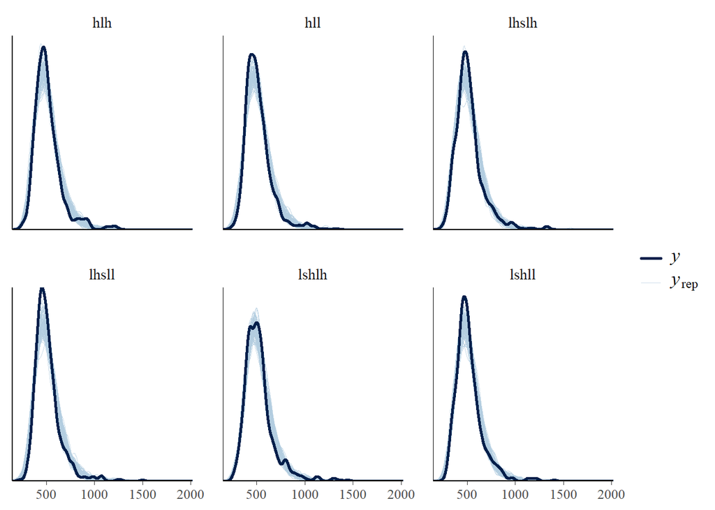

```r
pp_check(base_critical_WKSLP,
         type = "dens_overlay_grouped",
         group = "tune",
         ndraws = 100)
```

#### Model prediction plots

Below we plot the posterior RT distributions.

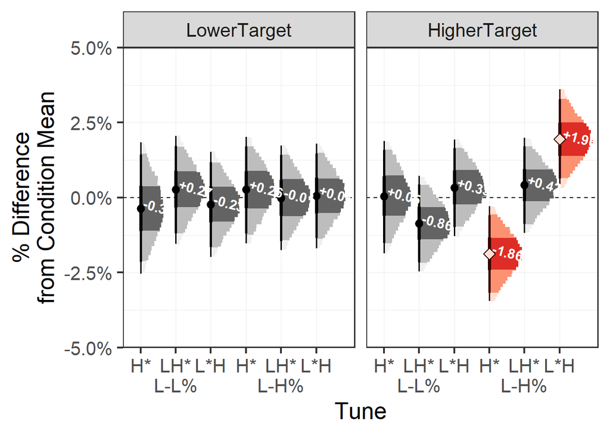

```r
# Data grid at covariate centers
dg <-
  sosdiss2::marginal_data_grid(model = base_critical_WKSLP,
                               'tune',
                               'condition',
                               center_log_freq = 0,
                               center_length = 0,
                               block = 0)

condition_difference_draws <-
  sosdiss2::get_condition_difference_draws(base_critical_WKSLP, dg,
                                           TUNE_ORDER = c("hll",
                                                          "lhsll",
                                                          "lshll",
                                                          "hlh",
                                                          "lhslh",
                                                          "lshlh"))
posterior_residrt_plot <-
  plot_posterior_rt_draws(condition_difference_draws,
                          slab_scale = .5,
                          facet_labels = c(higher="LowerTarget",
                                           lower="HigherTarget")) +
  scale_y_continuous(labels = scales::label_percent(), limits = c(-.05, .05))+
  scale_x_discrete(labels = c("H*", "LH*\nL-L%", "L*H", "H*", "LH*\nL-H%", "L*H"))

posterior_residrt_plot # x axis to be fixed up manually outside of R
```

```r
save_plot(posterior_residrt_plot,
          "pctchange",
          rootdir = "Figures",
          use_subfolders = TRUE,
          width =6.5, height = 3.25, scale = 1.5)
```

## Condition-only RTs

Below we wrangle the data for the model using the HF16 items.

```r
# Wrangle the dataset to use for modeling, including the HF16-adapted items
alldata_contrasts <- list(tune ~ sum_code + "hll",
                          condition ~ helmert_code | c('lower-higher',
                                                       'contr-scalar',
                                                       'noncontr-contr',
                                                       'unrelated-related'))

model_data_alldata <-
  exp_data |>
  flag_trial_outliers() |>
  dplyr::filter(condition != "filler",
                !is_outlier,
                is_correct) |>
  # Some centering and data transformations
  sosdiss2::wrangle_covariates() |>
  sosdiss2::join_metrics(metrics) |>
  dplyr::mutate(experiment_set = ifelse(condition %in% c('contrastive',
                                                         'noncontrastive',
                                                         'unrelated'),
                                        'hf16',
                                        condition),
                experiment_set = factor(experiment_set,
                                        levels = c('higher', 'lower','hf16')),
                condition = factor(condition, levels = c("higher", "lower",
                                                         "contrastive", "noncontrastive",
                                                         "unrelated"))) |>
  set_contrasts(alldata_contrasts)

# Contrast information
glimpse_contrasts(model_data_alldata, alldata_contrasts,add_namespace = TRUE)
```

```
# A tibble: 4 × 6
  factor             n level_names scheme                     reference     intercept
  <chr>          <int> <list>      <chr>                      <chr>         <chr>
1 tune               6 <chr [6]>   contrastable::sum_code     hll           grand mean
2 condition          5 <chr [5]>   contrastable::helmert_code <NA>          grand mean
3 original_item    311 <chr [311]> stats::contr.treatment     10contrastive mean(10contrastive)
4 experiment_set     3 <chr [3]>   stats::contr.treatment     higher        mean(higher)
```

```r
# Verifying the helmert direction
MASS::fractions(contrasts(model_data_alldata$condition))
```

```
               lower-higher contr-scalar noncontr-contr unrelated-related
higher         -1/2         -1/3         -1/4           -1/5
lower           1/2         -1/3         -1/4           -1/5
contrastive       0          2/3         -1/4           -1/5
noncontrastive    0            0          3/4           -1/5
unrelated         0            0            0            4/5
```

```r
# Set weak priors for the model
alldata_priors <-
  c(
    prior(normal(0,.03), class = 'b'),
    prior(lkj(2), class = 'cor'),
    prior(normal(.3,.4), class = 'sd')
  )

alldata_mdl_notune <-
  fit_generic_rt_model(bf(rt ~  center_log_freq + center_length + block + condition +
                            (1+condition|participant),
                          sigma ~ (1|participant)),
                       "alldata_mdl_notune",
                       data = model_data_alldata,
                       priors = alldata_priors)


alldata_mdl_notune2 <-
  fit_generic_rt_model(bf(rt ~  center_log_freq + center_length + block + condition +
                            (1+condition|participant) + (1|original_item),
                          sigma ~ (1|participant)+ (1|original_item)),
                       "alldata_mdl_notune2",
                       data = model_data_alldata,
                       priors = alldata_priors)

loo_compare(alldata_mdl_notune, alldata_mdl_notune2)
```

```
                    elpd_diff se_diff
alldata_mdl_notune2    0.0       0.0
alldata_mdl_notune  -409.0      33.5
```

```r
summary(alldata_mdl_notune2)
```

```
 Family: lognormal
  Links: mu = identity; sigma = log
Formula: rt ~ center_log_freq + center_length + block + condition + (1 + condition | participant) + (1 | original_item)
         sigma ~ (1 | participant) + (1 | original_item)
   Data: data (Number of observations: 7705)
  Draws: 4 chains, each with iter = 10000; warmup = 2000; thin = 2;
         total post-warmup draws = 16000

Multilevel Hyperparameters:
~original_item (Number of levels: 311)
                    Estimate Est.Error l-95% CI u-95% CI Rhat Bulk_ESS Tail_ESS
sd(Intercept)           0.07      0.00     0.06     0.07 1.00     8330    12236
sd(sigma_Intercept)     0.17      0.01     0.14     0.19 1.00     9442    13096

~participant (Number of levels: 63)
                                                        Estimate Est.Error l-95% CI u-95% CI Rhat Bulk_ESS Tail_ESS
sd(Intercept)                                               0.13      0.01     0.11     0.15 1.00     3082     5858
sd(conditionlowerMhigher)                                   0.01      0.01     0.00     0.03 1.00     6393     8938
sd(conditioncontrMscalar)                                   0.03      0.01     0.01     0.05 1.00     9039     8217
sd(conditionnoncontrMcontr)                                 0.03      0.01     0.01     0.05 1.00     6825     5140
sd(conditionunrelatedMrelated)                              0.05      0.01     0.03     0.06 1.00     9241    11662
sd(sigma_Intercept)                                         0.22      0.02     0.18     0.26 1.00     5979    10151
cor(Intercept,conditionlowerMhigher)                        0.04      0.30    -0.55     0.62 1.00    14792    13625
cor(Intercept,conditioncontrMscalar)                        0.07      0.20    -0.33     0.47 1.00    14066    13113
cor(conditionlowerMhigher,conditioncontrMscalar)           -0.12      0.34    -0.71     0.56 1.00     3381     6019
cor(Intercept,conditionnoncontrMcontr)                     -0.03      0.21    -0.44     0.38 1.00    13820    13617
cor(conditionlowerMhigher,conditionnoncontrMcontr)         -0.16      0.34    -0.74     0.54 1.00     4175     6936
cor(conditioncontrMscalar,conditionnoncontrMcontr)          0.43      0.25    -0.13     0.84 1.00     8664    11316
cor(Intercept,conditionunrelatedMrelated)                  -0.09      0.17    -0.41     0.24 1.00    13122    13836
cor(conditionlowerMhigher,conditionunrelatedMrelated)      -0.13      0.33    -0.72     0.54 1.00     2997     4929
cor(conditioncontrMscalar,conditionunrelatedMrelated)       0.39      0.23    -0.11     0.80 1.00     5968    10957
cor(conditionnoncontrMcontr,conditionunrelatedMrelated)     0.37      0.24    -0.14     0.79 1.00     7189     9580

Regression Coefficients:
                           Estimate Est.Error l-95% CI u-95% CI Rhat Bulk_ESS Tail_ESS
Intercept                      6.26      0.02     6.23     6.29 1.00     1178     2782
sigma_Intercept               -1.71      0.03    -1.77    -1.65 1.00     3936     7686
center_log_freq               -0.03      0.00    -0.04    -0.03 1.00     7817    11385
center_length                  0.01      0.00     0.00     0.01 1.00     8053    11056
block                         -0.01      0.00    -0.01    -0.01 1.00    15030    13656
conditionlowerMhigher         -0.00      0.01    -0.03     0.02 1.00     7296    10928
conditioncontrMscalar          0.01      0.01    -0.01     0.03 1.00     8411    12339
conditionnoncontrMcontr        0.05      0.01     0.02     0.07 1.00     8372    11893
conditionunrelatedMrelated     0.09      0.01     0.06     0.11 1.00     9524    12611

Draws were sampled using sample(hmc). For each parameter, Bulk_ESS
and Tail_ESS are effective sample size measures, and Rhat is the potential
scale reduction factor on split chains (at convergence, Rhat = 1).
```

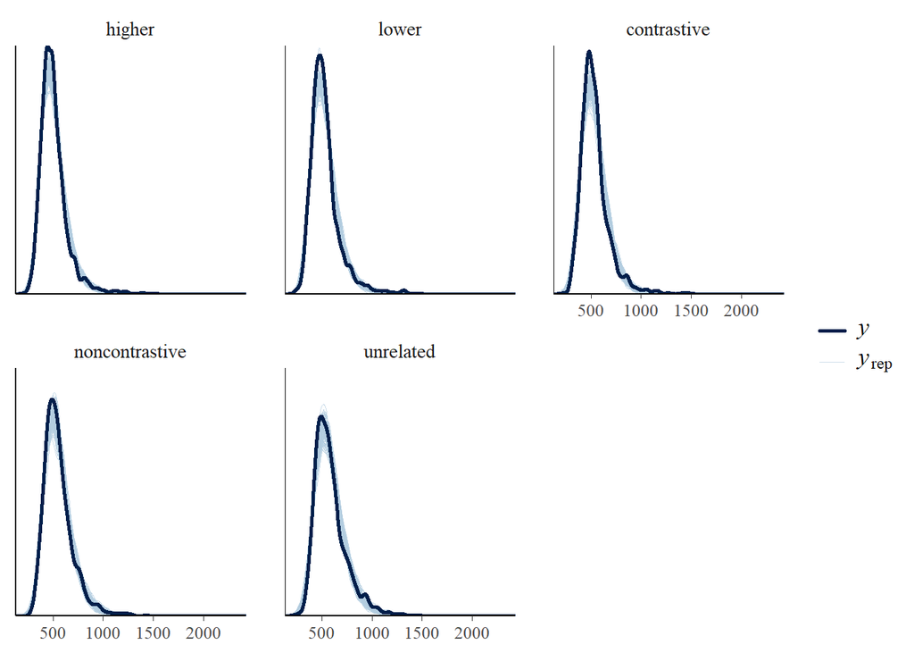

```r
pp_check(alldata_mdl_notune2,
         type = "dens_overlay_grouped",
         group = "condition",
         ndraws = 100)
```

Make the barplot figure.

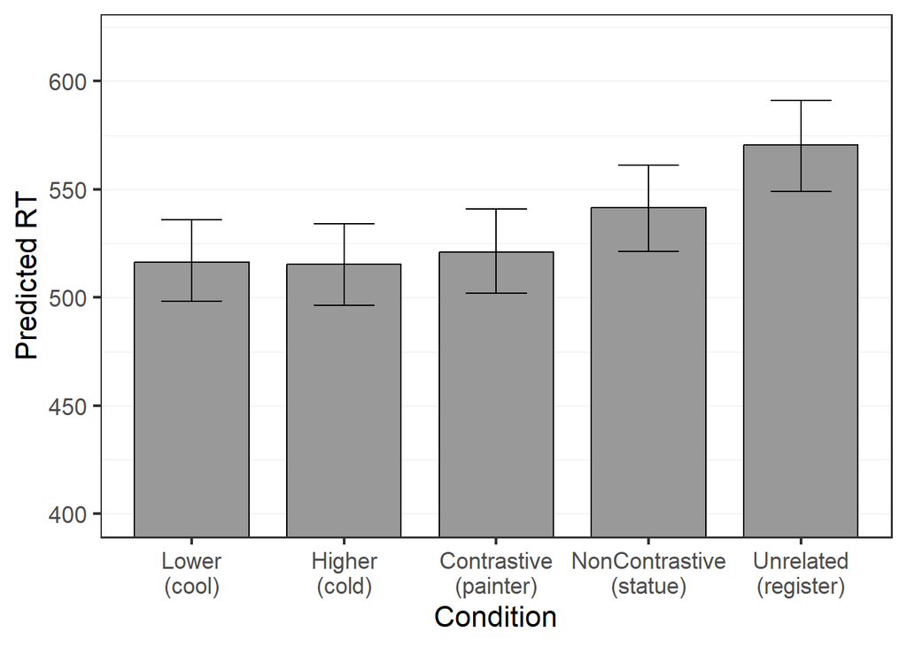

```r
datagrid_without_tunes <-
  marginal_data_grid(model = alldata_mdl_notune2,
                     'condition',
                     center_log_freq = 0,
                     center_length = 0,
                     block = 0)

alldata_cond_draws <- tidybayes::add_epred_draws(datagrid_without_tunes,
                                                 alldata_mdl_notune2,
                                                 ndraws = NULL,
                                                 seed = 11,
                                                 re_formula = NA)

predicted_condition_rt_plot <-
  alldata_cond_draws |>
  mean_hdi(.width = c(.95)) |>
  ggplot(aes(x = condition, y = .epred, ymin = .lower, ymax = .upper)) +
  # geom_point() +
  geom_col(width = .75, color = 'black', fill = 'gray60') +
  geom_errorbar(width = .4) +
  coord_cartesian(ylim = c(400,620)) +
  theme_bw(base_size = 16) +
  scale_x_discrete(labels = c("Lower\n(cool)",
                              "Higher\n(cold)",
                              "Contrastive\n(painter)",
                              "NonContrastive\n(statue)",
                              "Unrelated\n(register)"))+
  ylab("Predicted RT") +
  xlab("Condition") +
  theme(
    panel.grid = element_line(linewidth = .3),
    panel.grid.major.x = element_blank())

predicted_condition_rt_plot
```

```r
save_plot(predicted_condition_rt_plot, "predicted_condition_RT",
          width = 8, height = 4.5)
```

## Inline statistics

Inline statistics are reported using the latex commands created below, see https://tsostaricsblog.netlify.app/posts/latexswitch/ for more information.

```r
suppressWarnings(
  broom.mixed::tidy(base_critical_WKSLP,
                    effects = "fixed",
                    conf.int=TRUE)
) |>
  mutate(pct_change = round(100*(exp(estimate) - 1),2),
         term = casefold(gsub(":", "i", term)),
         term = gsub("[)(]", "", term),
         across(all_of(c('estimate', 'conf.low', 'conf.high')), ~round(.,3))) |>
  make_latex_switch(fstring = "$(\\hat\\beta = {estimate}, \\%\\Delta= {pct_change}\\%, CI=[{conf.low},{conf.high}])$",
                    macroname = "tuneStat",
                    add_found_boolean = FALSE)
```

```
\ExplSyntaxOn
 \setboolean{found}{false}
 \NewDocumentCommand \tuneStat{ m }
   {
     \str_case_e:nn { \str_foldcase:e { #1 } }
       {
         { intercept } { $(\hat\beta = 6.215, \%\Delta= 49939.68\%, CI=[6.178,6.253])$ \setboolean{found}{true} }
         { sigma_intercept } { $(\hat\beta = -1.735, \%\Delta= -82.35\%, CI=[-1.802,-1.667])$ \setboolean{found}{true} }
         { center_log_freq } { $(\hat\beta = -0.027, \%\Delta= -2.68\%, CI=[-0.035,-0.019])$ \setboolean{found}{true} }
         { center_length } { $(\hat\beta = 0.012, \%\Delta= 1.17\%, CI=[0.005,0.018])$ \setboolean{found}{true} }
         { block } { $(\hat\beta = -0.012, \%\Delta= -1.2\%, CI=[-0.015,-0.009])$ \setboolean{found}{true} }
         { tunehlh } { $(\hat\beta = -0.019, \%\Delta= -1.86\%, CI=[-0.035,-0.003])$ \setboolean{found}{true} }
         { tunelhslh } { $(\hat\beta = 0.004, \%\Delta= 0.42\%, CI=[-0.012,0.02])$ \setboolean{found}{true} }
         { tunelhsll } { $(\hat\beta = -0.009, \%\Delta= -0.86\%, CI=[-0.025,0.007])$ \setboolean{found}{true} }
         { tunelshlh } { $(\hat\beta = 0.019, \%\Delta= 1.96\%, CI=[0.003,0.036])$ \setboolean{found}{true} }
         { tunelshll } { $(\hat\beta = 0.003, \%\Delta= 0.33\%, CI=[-0.013,0.019])$ \setboolean{found}{true} }
         { conditionhigher } { $(\hat\beta = 0.006, \%\Delta= 0.56\%, CI=[-0.019,0.03])$ \setboolean{found}{true} }
         { tunehlhiconditionhigher } { $(\hat\beta = 0.021, \%\Delta= 2.16\%, CI=[-0.001,0.044])$ \setboolean{found}{true} }
         { tunelhslhiconditionhigher } { $(\hat\beta = -0.004, \%\Delta= -0.43\%, CI=[-0.026,0.018])$ \setboolean{found}{true} }
         { tunelhslliconditionhigher } { $(\hat\beta = 0.011, \%\Delta= 1.14\%, CI=[-0.011,0.033])$ \setboolean{found}{true} }
         { tunelshlhiconditionhigher } { $(\hat\beta = -0.019, \%\Delta= -1.86\%, CI=[-0.041,0.003])$ \setboolean{found}{true} }
         { tunelshlliconditionhigher } { $(\hat\beta = -0.006, \%\Delta= -0.56\%, CI=[-0.027,0.016])$ \setboolean{found}{true} }
       }
     \ifthenelse{\boolean{found}}{}{{\color{red} \large ERROR}}
     \setboolean{found}{false}
   }
 \cs_generate_variant:Nn \str_foldcase:n { e }
 \ExplSyntaxOff
```

```r
sosdiss2::model_to_latex_switch(alldata_mdl_notune2,
                                "conditionStat",
                                add_found_boolean = FALSE)
```

```
\ExplSyntaxOn
 \setboolean{found}{false}
 \NewDocumentCommand \conditionStat{ m }
   {
     \str_case_e:nn { \str_foldcase:e { #1 } }
       {
         { intercept } { $(\hat\beta = 6.26, CI=[6.23,6.29])$ \setboolean{found}{true} }
         { sigma_intercept } { $(\hat\beta = -1.71, CI=[-1.77,-1.65])$ \setboolean{found}{true} }
         { center_log_freq } { $(\hat\beta = -0.03, CI=[-0.04,-0.03])$ \setboolean{found}{true} }
         { center_length } { $(\hat\beta = 0.01, CI=[0,0.01])$ \setboolean{found}{true} }
         { block } { $(\hat\beta = -0.01, CI=[-0.01,-0.01])$ \setboolean{found}{true} }
         { conditionlowermhigher } { $(\hat\beta = 0, CI=[-0.03,0.02])$ \setboolean{found}{true} }
         { conditioncontrmscalar } { $(\hat\beta = 0.01, CI=[-0.01,0.03])$ \setboolean{found}{true} }
         { conditionnoncontrmcontr } { $(\hat\beta = 0.05, CI=[0.02,0.07])$ \setboolean{found}{true} }
         { conditionunrelatedmrelated } { $(\hat\beta = 0.09, CI=[0.06,0.11])$ \setboolean{found}{true} }
       }
     \ifthenelse{\boolean{found}}{}{{\color{red} \large ERROR}}
     \setboolean{found}{false}
   }
 \cs_generate_variant:Nn \str_foldcase:n { e }
 \ExplSyntaxOff
```